# Ford Ka Segmentation Exercise

Krisha Lim

# Data Cleaning

First we load the packages we will use for this analysis.

```r
pacman::p_load(dplyr, tidyverse, ggplot2, here, readxl, janitor, modelsummary, kableExtra, cluster, factoextra)
```

Next, we load the demographic data and psychographic data and merge these two files by `respondent_id`.

```r
dg <- read_excel(here("data", "Ford Ka (Student).xls"),
                 sheet = "Demographic Data",
                 skip = 6) %>%
  clean_names()

psyc <- read_excel(here("data", "Ford Ka (Student).xls"),
                   sheet = "Psychographic Data",
                   skip = 6) %>%
  clean_names()

ford <- left_join(dg, psyc, by = c("respondent_number"))
```

Instead of loading each reference table in the spreadsheet’s Demographics Code sheet, I converted the relevant variables into a factor variable and used the code sheet’s information as the levels.

# Crosstabs Analysis

Next, we run crosstabs to check whether different demographic variables separate “Ka Choosers” from “Ka Non-Choosers”. The results are in line with Student # 76174135.

| preference_group |  | Male | Female |
| --- | --- | --- | --- |
| Ka Chooser (top 3) | % row | 46.6 | 53.4 |
| Ka Non-Chooser (bottom 3) | % row | 50.0 | 50.0 |
| Middle (middle 4) | % row | 64.5 | 35.5 |
| All | % row | 52.0 | 48.0 |

| preference_group |  | Married | Living Together | Single |
| --- | --- | --- | --- | --- |
| Ka Chooser (top 3) | % row | 56.9 | 12.1 | 31.0 |
| Ka Non-Chooser (bottom 3) | % row | 47.2 | 8.3 | 44.4 |
| Middle (middle 4) | % row | 43.5 | 12.9 | 43.5 |
| All | % row | 50.8 | 11.2 | 38.0 |

| preference_group |  | Yes | No |
| --- | --- | --- | --- |
| Ka Chooser (top 3) | % row | 11.2 | 88.8 |
| Ka Non-Chooser (bottom 3) | % row | 11.1 | 88.9 |
| Middle (middle 4) | % row | 25.8 | 74.2 |
| All | % row | 14.8 | 85.2 |

| preference_group |  | 0 child | 1 child | >1 child |
| --- | --- | --- | --- | --- |
| Ka Chooser (top 3) | % row | 53.4 | 25.0 | 21.6 |
| Ka Non-Chooser (bottom 3) | % row | 62.5 | 16.7 | 20.8 |
| Middle (middle 4) | % row | 66.1 | 11.3 | 22.6 |
| All | % row | 59.2 | 19.2 | 21.6 |

| preference_group |  | <100K | 100K-150K | 150K-200K | 200K-250K | 250K-300K | >300K |
| --- | --- | --- | --- | --- | --- | --- | --- |
| Ka Chooser (top 3) | % row | 9.5 | 16.4 | 15.5 | 16.4 | 24.1 | 18.1 |
| Ka Non-Chooser (bottom 3) | % row | 6.9 | 20.8 | 22.2 | 22.2 | 16.7 | 11.1 |
| Middle (middle 4) | % row | 11.3 | 19.4 | 19.4 | 17.7 | 17.7 | 14.5 |
| All | % row | 9.2 | 18.4 | 18.4 | 18.4 | 20.4 | 15.2 |

| preference_group |  | <25 | 25-29 | 30-34 | 35-39 | 40-44 | >44 |
| --- | --- | --- | --- | --- | --- | --- | --- |
| Ka Chooser (top 3) | % row | 8.6 | 15.5 | 19.8 | 9.5 | 31.0 | 15.5 |
| Ka Non-Chooser (bottom 3) | % row | 4.2 | 18.1 | 16.7 | 15.3 | 20.8 | 25.0 |
| Middle (middle 4) | % row | 17.7 | 19.4 | 19.4 | 14.5 | 19.4 | 9.7 |
| All | % row | 9.6 | 17.2 | 18.8 | 12.4 | 25.2 | 16.8 |

# Clustering Analysis

`set.seed(2022)` allows me to reproduce the same results, as the order of clusters change.

```r
ford_psyc <- select(ford, q1:q62)
set.seed(2022)
k3 <- kmeans(ford_psyc, centers = 3, nstart = 25)
set.seed(2022)
k4 <- kmeans(ford_psyc, centers = 4, nstart = 25)
set.seed(2022)
k5 <- kmeans(ford_psyc, centers = 5, nstart = 25)
```

## 3 Clusters

The three clusters have the following sizes: 107, 65, 78

```
##         q1       q2       q3       q4       q5       q6       q7       q8
## 1 4.728972 2.448598 3.943925 3.308411 2.411215 4.018692 3.822430 3.915888
## 2 4.015385 3.769231 5.938462 6.015385 6.015385 3.969231 3.800000 4.107692
## 3 6.512821 6.512821 3.884615 4.025641 4.012821 3.974359 4.025641 3.756410
##         q9      q10      q11      q12      q13      q14      q15      q16
## 1 3.859813 3.878505 3.971963 4.084112 3.934579 6.130841 6.224299 5.308411
## 2 3.769231 3.815385 3.876923 4.138462 4.169231 3.984615 4.169231 3.923077
## 3 4.076923 4.051282 4.089744 4.000000 3.910256 1.512821 3.923077 3.910256
##        q17      q18      q19      q20      q21      q22      q23      q24
## 1 6.205607 5.336449 5.485981 5.383178 6.121495 6.186916 2.542056 2.345794
## 2 2.000000 4.015385 4.215385 4.061538 4.200000 4.107692 3.876923 3.692308
## 3 4.064103 3.858974 3.987179 1.512821 3.846154 4.089744 6.487179 1.320513
##        q25      q26      q27      q28      q29      q30      q31      q32
## 1 1.934579 1.822430 2.691589 1.897196 2.700935 2.598131 4.672897 4.112150
## 2 4.169231 3.800000 4.169231 4.030769 4.107692 3.892308 6.030769 6.046154
```

[output cut: 17 more lines]

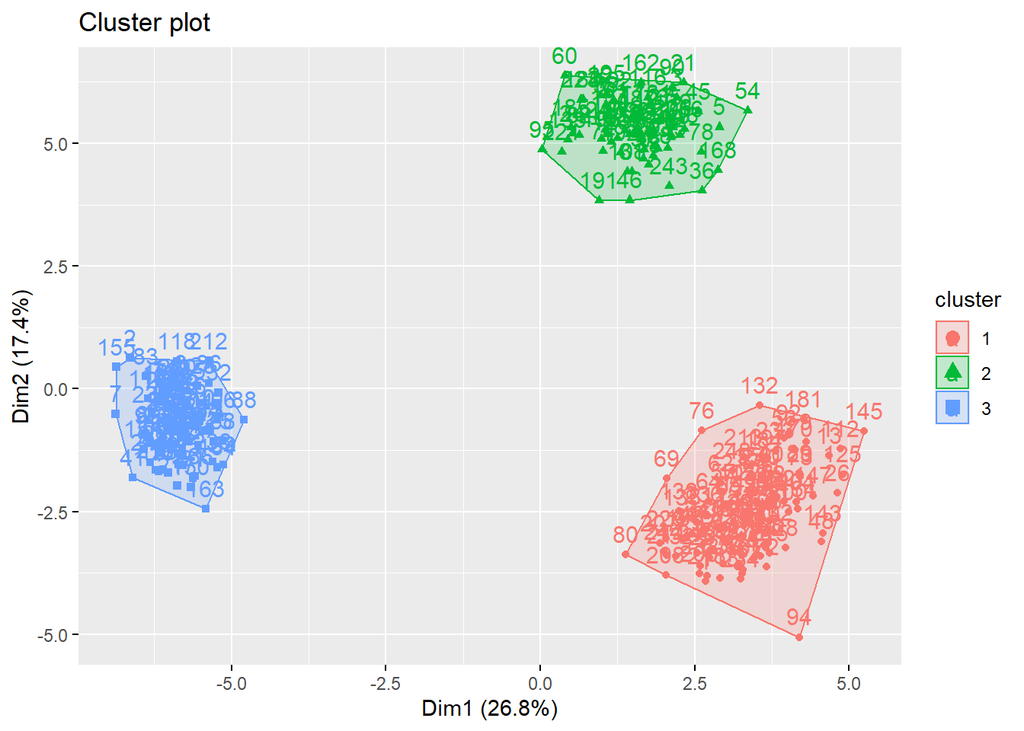

## 4 Clusters

The four clusters have the following sizes: 32, 65, 78, 75. These results replicate the numbers in the file `Ford Ka 4-Cluster Results - no variables missing`.

```
##         q1       q2       q3       q4       q5       q6       q7       q8
## 1 6.500000 3.562500 3.781250 1.500000 3.937500 4.218750 3.562500 3.843750
## 2 4.015385 3.769231 5.938462 6.015385 6.015385 3.969231 3.800000 4.107692
## 3 6.512821 6.512821 3.884615 4.025641 4.012821 3.974359 4.025641 3.756410
## 4 3.973333 1.973333 4.013333 4.080000 1.760000 3.933333 3.933333 3.946667
##         q9      q10      q11      q12      q13      q14      q15      q16
## 1 3.718750 3.750000 4.000000 3.875000 3.843750 6.468750 6.562500 3.843750
## 2 3.769231 3.815385 3.876923 4.138462 4.169231 3.984615 4.169231 3.923077
## 3 4.076923 4.051282 4.089744 4.000000 3.910256 1.512821 3.923077 3.910256
## 4 3.920000 3.933333 3.960000 4.173333 3.973333 5.986667 6.080000 5.933333
##        q17      q18      q19      q20      q21      q22      q23      q24
## 1 6.468750 3.843750 4.281250 4.218750 6.437500 6.562500 3.968750 3.625000
## 2 2.000000 4.015385 4.215385 4.061538 4.200000 4.107692 3.876923 3.692308
## 3 4.064103 3.858974 3.987179 1.512821 3.846154 4.089744 6.487179 1.320513
## 4 6.093333 5.973333 6.000000 5.880000 5.986667 6.026667 1.933333 1.800000
```

[output cut: 25 more lines]

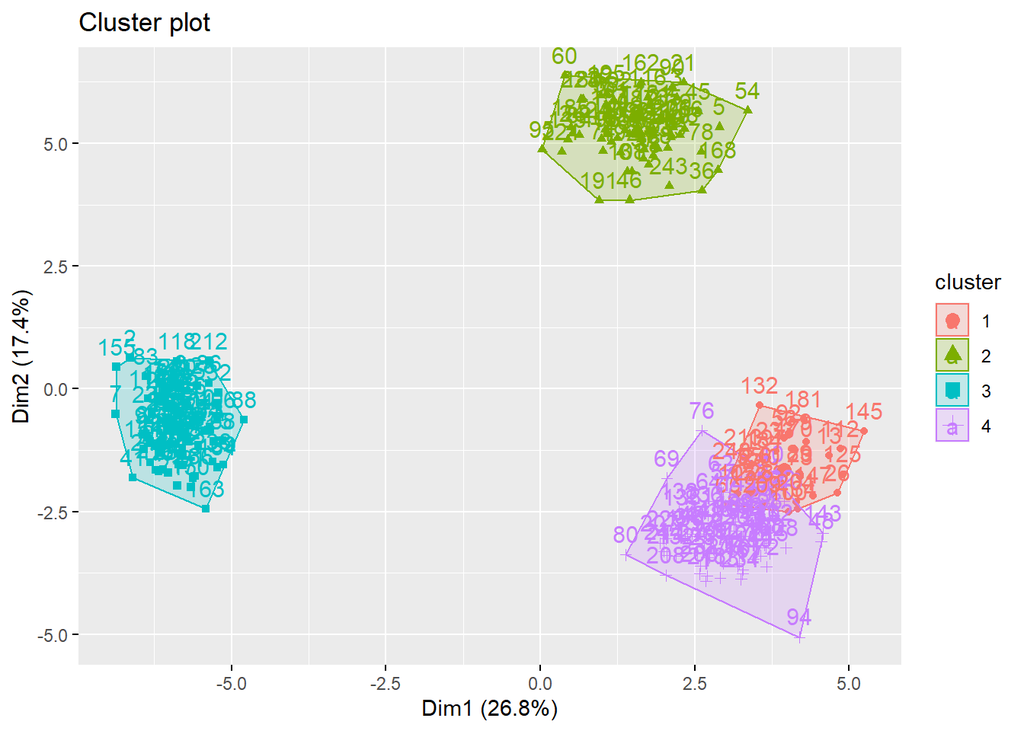

## 5 Clusters

The five clusters have the following sizes: 32, 37, 38, 65, 78. **I don’t get the same small cluster as noted by the students**

```
##         q1       q2       q3       q4       q5       q6       q7       q8
## 1 6.500000 3.562500 3.781250 1.500000 3.937500 4.218750 3.562500 3.843750
## 2 4.216216 1.972973 4.162162 3.918919 1.783784 3.864865 4.081081 3.513514
## 3 3.736842 1.973684 3.868421 4.236842 1.736842 4.000000 3.789474 4.368421
## 4 4.015385 3.769231 5.938462 6.015385 6.015385 3.969231 3.800000 4.107692
## 5 6.512821 6.512821 3.884615 4.025641 4.012821 3.974359 4.025641 3.756410
##         q9      q10      q11      q12      q13      q14      q15      q16
## 1 3.718750 3.750000 4.000000 3.875000 3.843750 6.468750 6.562500 3.843750
## 2 3.405405 4.351351 3.918919 4.675676 4.567568 6.027027 6.054054 5.945946
## 3 4.421053 3.526316 4.000000 3.684211 3.394737 5.947368 6.105263 5.921053
## 4 3.769231 3.815385 3.876923 4.138462 4.169231 3.984615 4.169231 3.923077
## 5 4.076923 4.051282 4.089744 4.000000 3.910256 1.512821 3.923077 3.910256
##        q17      q18      q19      q20      q21      q22      q23      q24
## 1 6.468750 3.843750 4.281250 4.218750 6.437500 6.562500 3.968750 3.625000
## 2 5.891892 5.864865 5.810811 5.918919 5.918919 5.891892 1.918919 1.837838
```

[output cut: 33 more lines]

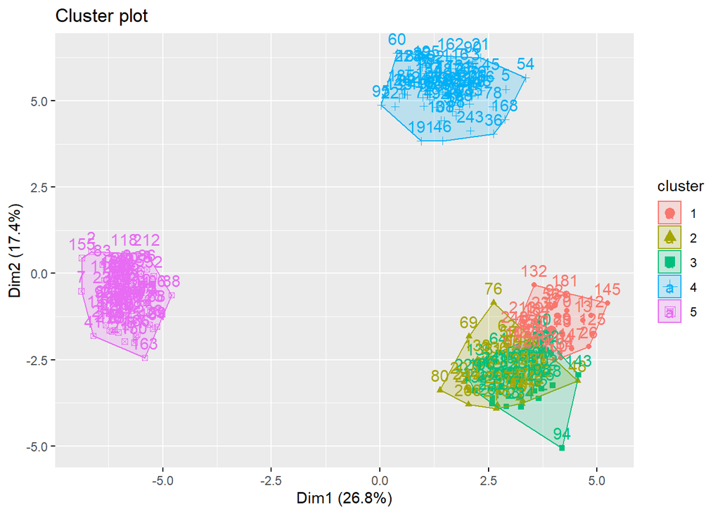

# Optimal clusters

The **Elbow Method** suggests that 4 is the optimal number of clusters as this appears to be the bend in the graph.

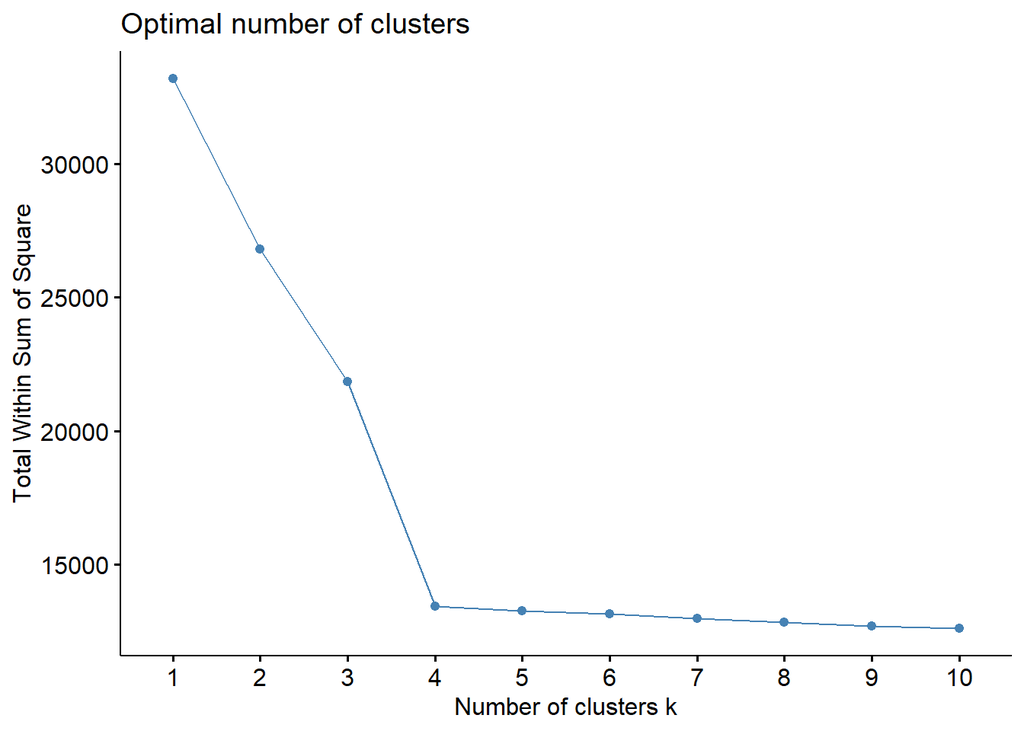

```r
set.seed(2022)

fviz_nbclust(ford_psyc, kmeans, method = "wss")
```

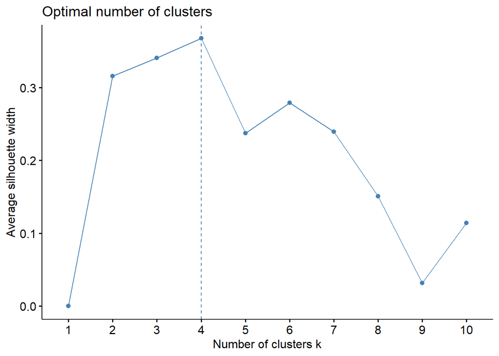

```r
fviz_nbclust(ford_psyc, kmeans, method = "silhouette")
```

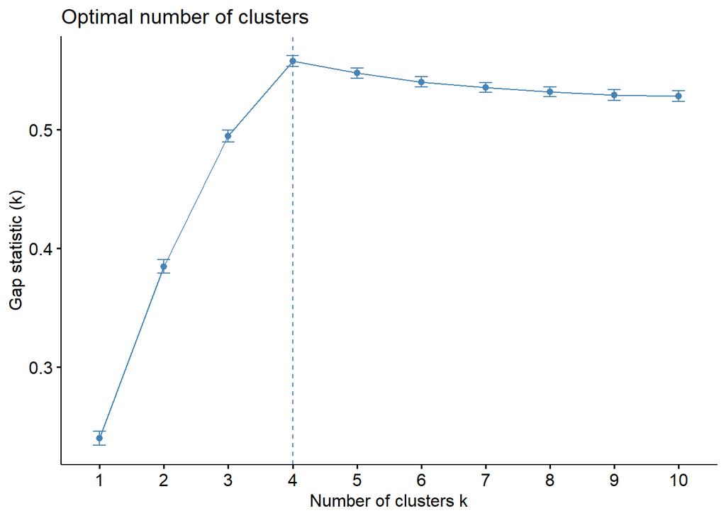

```r
set.seed(2022)
gap_stat <- clusGap(ford_psyc, FUN = kmeans, nstart = 25,
                    K.max = 10, B = 50)

fviz_gap_stat(gap_stat)
```